# Experiment 1

## NOA station vs. GPM-IMERG satellite over Attiki (Greece)

### Introduction

This is a presentation of the scalegram methodology, applied for the validation of satellite precipitation product. Here, we use the [GPM IMERGHH data product](https://disc.gsfc.nasa.gov/datasets/GPM_3IMERGHH_05/summary) and the dense precipitation network of National Observatory of Athens for Attiki (Greece) region.

### Data

**Satellite data (gpm)**

- Dataset: GPM IMERG Final Precipitation L3 Half Hourly 0.1 degree x 0.1 degree V05
- Date Range: 2017-11-30 to 2017-12-31
- Spatial Region 23.269, 37.786, 23.906, 38.467
- Variables: precipitationCal
- Format: netCDF 4

The data were cropped to [2017-12-01, 2017-12-31] period. Then all grid cells with no gauge closer than 0.5 deg were removed.

Right now working with the 1d product downloaded from knmi, which does not correspond to the 30-min. Have to check code and version.

**Instrumental data (noa)**

- Dataset: NOA automatic precipitation network
- 10 minute precipitation
- Date Range: 2017-12-01, 2017-12-31
- Spatial Region 23.269, 37.786, 23.906, 38.467
- Variables: rainfall
- Format: txt

Stations above 400 meters were removed.

**Grid cell centers vs. Stations locations**

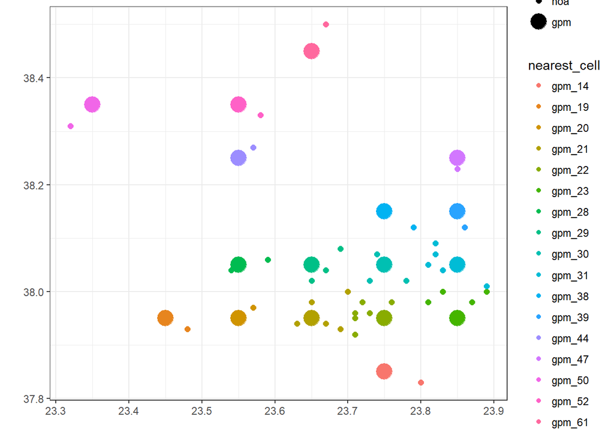

**Monthly heterogeneity**

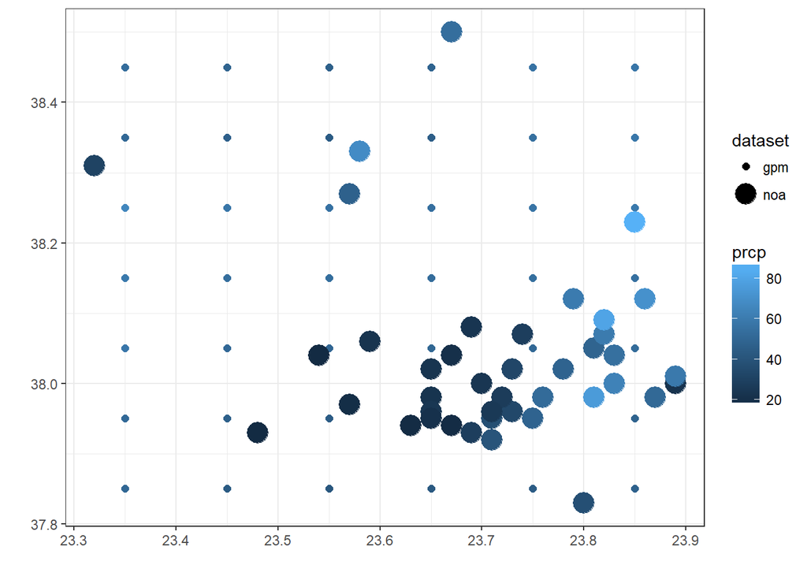